# Data cleaning and summarization for HDL lipidomics of Ghana samples

Chenghao Zhu

September 04, 2018

```r
pkgs = c("dplyr", "reshape2", "stringr", "Metabase", "xlsx", "tibble")
for(pkg in pkgs){
    library(pkg, quietly=TRUE, verbose=FALSE, warn.conflicts=FALSE,
            character.only=TRUE)
}
```

# Part 1: read and clean data

Because the positive mode and negative mode data are in separate sheets, so they were first imported in to 2 separate objects, to be merged later.

```r
pos = import_wcmc_excel(
    file = "../raw_data/MX388497_Zhu_CSH_Submit.xlsx",
    sheet = "Positive Submit",
    conc_range = "K8:DB1742",
    sample_range = "J1:DB7",
    feature_range = "A7:J1742",
    InChIKey = "InChI Key",
    experiment_type = "Lipidomcis"
)
neg = import_wcmc_excel(
    file = "../raw_data/MX388497_Zhu_CSH_Submit.xlsx",
    sheet = "Negative Submit",
    conc_range = "K8:DD610",
    sample_range = "J1:DD7",
    feature_range = "A7:J610",
    InChIKey = "InChI Key",
    experiment_type = "Lipidomics"
)
```

Remove all the features that are unknown, then calculate the mean, standards deviation, and coefficient of variance of the qc samples, and merge the two objects into one.

```r
pos = subset_features(pos, !is.na(pos$feature_data$InChIKey))
neg = subset_features(neg, !is.na(neg$feature_data$InChIKey))
pos = collapse_QC(pos, qc_names = paste0("Biorec00", 1:8))
neg = collapse_QC(neg, qc_names = paste0("Biorec00", 1:9))
pos = subset_samples(pos, !grepl("^MtdBlnk", sampleNames(pos)))
neg = subset_samples(neg, !grepl("^MtdBlnk", sampleNames(neg)))
pos$feature_data$ESI = "pos"
neg$feature_data$ESI = "neg"
featureNames(pos) = paste0("pos", 1:nfeatures(pos))
featureNames(neg) = paste0("neg", 1:nfeatures(neg))
lpd = LipidomicsSet(
    conc_table = conc_table(rbind(pos$conc_table, neg$conc_table)),
    sample_table = pos$sample_table,
    feature_data = feature_data(rbind(pos$feature_data, neg$feature_data)),
    experiment_data = pos$experiment_data
)
```

Missing values.

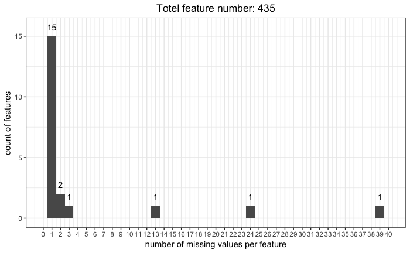

```r
plot_hist_NA(lpd)
```

```r
lpd = subset_features(
    lpd, apply(conc_table(lpd), 1, function(x) sum(is.na(x)) < 10) )
lpd = transform_by_feature(
    lpd, function(x) ifelse(is.na(x), min(x, na.rm = TRUE)/2, x)
)
plot_hist_NA(lpd)
```

```
Error: No NA detected. You are good to go!
```

Read the internal standards and calibrate lipid species. The 3 PI species were removed because a PI interna standard was not ran.

```r
standards = read.csv("../raw_data/wcmc_lipidomics_standards.csv")
feature_data(lpd)$class = assign_lipid_class(feature_data(lpd)$Annotation)
experiment_data(lpd)$institute = "West Coast Metabolomics Center"
experiment_data(lpd)$sample_volumn_ul = 20
experiment_data(lpd)$internal_standards = standards
lpd = subset_features(
    lpd, !lpd$feature_data$class %in% c("CUDA", "PI", "AC"))
lpd = calibrate_lipidomics_wcmc(lpd, cid = "InChIKey",
                                     class = "class", ESI = "ESI")
```

Some features were detected on both positive and negative mode. Only the one with a lower CV is kept.

```r
lpd = filter_by_cv(lpd, cv = "qc_cv", cid = "InChIKey")
lpd$feature_data$Annotation = lipid_name_formater(lpd$feature_data$Annotation)
lpd$feature_data$Annotation = make.unique(lpd$feature_data$Annotation)
featureNames(lpd) = lpd$feature_data$Annotation
lpd
```

```
             >>>>>> Metabolomics Experiment <<<<<<
conc_table():           [  80 samples  and 313 features          ]
sample_table():         [  80 samples  and   6 sample  variables ]
feature_data():         [ 313 features and  16 feature variables ]
experiment_data():      [   9 experiment attributes              ]
```

The data has 313 lipid species and 80 samples.

Quality controls:

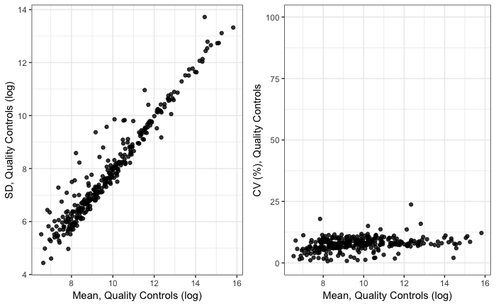

```r
plot_qc(lpd, mean = "qc_mean", sd = "qc_sd", cv = "qc_cv")
```